# examples_0401

A polynomial, $p(x)$, is given in factored form.
$$p(x)~=~-(x+7)\cdot
(x-5)^{2}$$

Which of the following graphs matches $y=p(x)$?

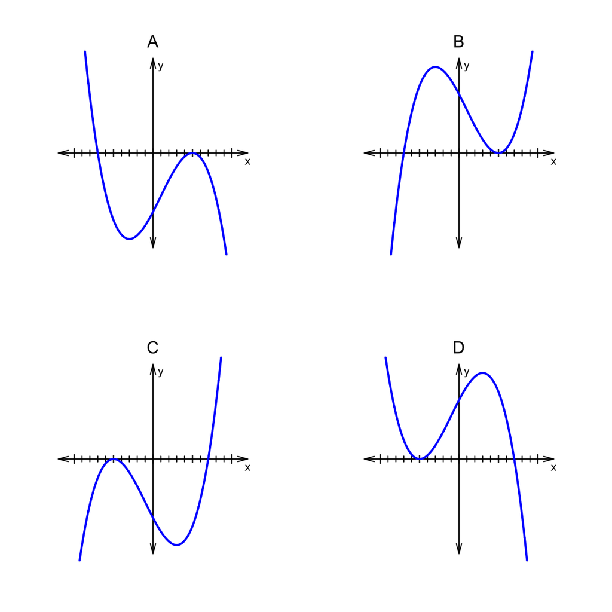

ABCD

First, consider the end behavior. If you expanded the polynomial into standard form, the highest-degree term would be $-x^{3}$.

$$p(x)~=~-x^{3}+\ldots$$

The highest degree term has a negative coefficient and an odd degree, so the end behavior is **"up,down"**. Or, more formally, $\lim\limits_{x\to-\infty} p(x) ~=~ \infty$ and $\lim\limits_{x\to\infty} p(x) ~=~ -\infty$.

Next, we consider the roots. From the factored form, $p(x)~=~-(x+7)\cdot (x-5)^{2}$, it is easy to see (see [zero-product property](https://en.wikipedia.org/wiki/Zero-product_property)) that $x=-7$ or $x=5$ makes the polynomial output 0.

$$p(-7)~=~-(-7+7)\cdot
(-7-5)^{2}~=~0$$
$$p(5)~=~-(5+7)\cdot
(5-5)^{2}~=~0$$

We predict that at $x=5$ there is a double root (multiplicity of 2) because the corresponding factor is squared. Graphically, we expect the curve to "bounce" off the $x$ axis at $x=5$. At the other root, we expect the curve to cut through the $x$ axis.

Anyway, based on this analysis, we can produce a [sign](https://en.wikipedia.org/wiki/Sign_function) graph of the polynomial.

| $x$ interval or value | sign analysis of $p(x)~=~-(x+7)\cdot (x-5)^{2}$ | sign |
| --- | --- | --- |
| $(-\infty,-7)$ | $-(\mathrm{neg})\cdot (\mathrm{neg})^{2}$ | $1$ |
| $-7$ | $-(\mathrm{zero})\cdot (\mathrm{neg})^{2}$ | $0$ |
| $(-7,5)$ | $-(\mathrm{pos})\cdot (\mathrm{neg})^{2}$ | $-1$ |
| $5$ | $-(\mathrm{pos})\cdot (\mathrm{zero})^{2}$ | $0$ |
| $(5,\infty)$ | $-(\mathrm{pos})\cdot (\mathrm{pos})^{2}$ | $-1$ |

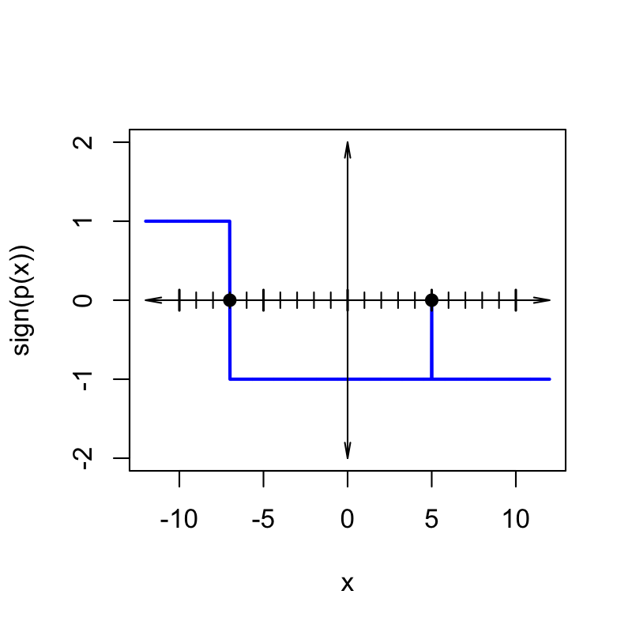

And only one option matches.

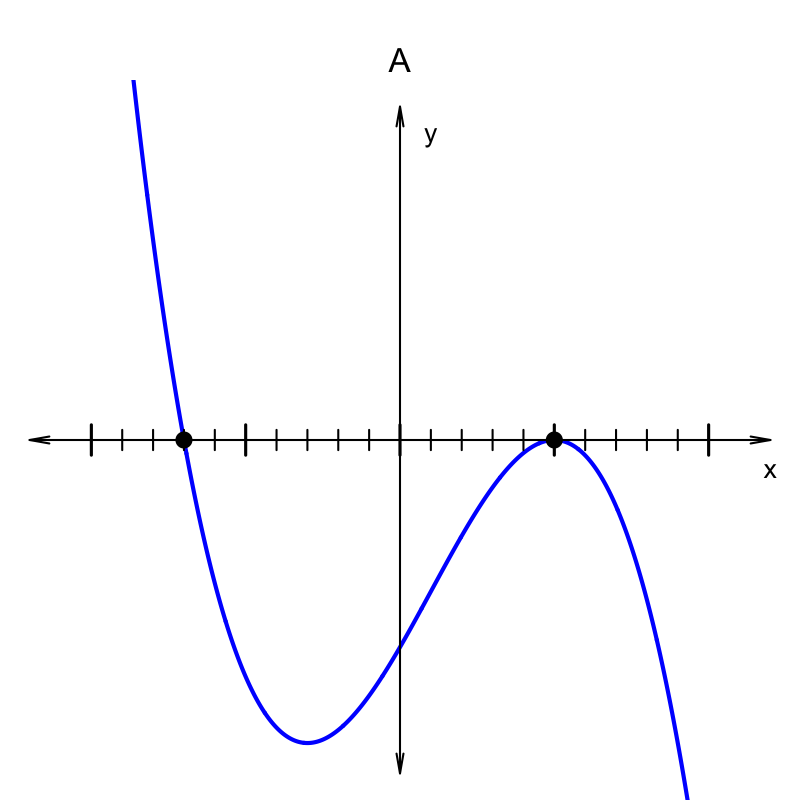

A polynomial, $p(x)$, is given in factored form.
$$p(x)~=~x^{2}\cdot (x-3)\cdot
(x-7)$$

Which of the following graphs matches $y=p(x)$?

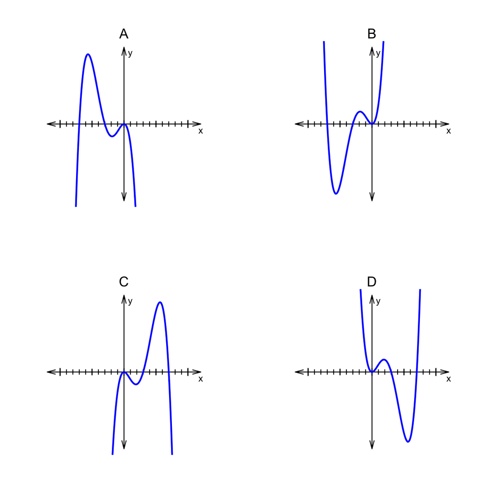

ABCD

First, consider the end behavior. If you expanded the polynomial into standard form, the highest-degree term would be $x^{4}$.

$$p(x)~=~x^{4}+\ldots$$

The highest degree term has a positive coefficient and an even degree, so the end behavior is **"up,up"**. Or, more formally, $\lim\limits_{x\to-\infty} p(x) ~=~ \infty$ and $\lim\limits_{x\to\infty} p(x) ~=~ \infty$.

Next, we consider the roots. From the factored form, $p(x)~=~x^{2}\cdot (x-3)\cdot (x-7)$, it is easy to see (see [zero-product property](https://en.wikipedia.org/wiki/Zero-product_property)) that $x=0$ or $x=3$ or $x=7$ makes the polynomial output 0.

$$p(0)~=~0^{2}\cdot (0-3)\cdot
(0-7)~=~0$$
$$p(3)~=~3^{2}\cdot
(3-3)\cdot (3-7)~=~0$$
$$p(7)~=~7^{2}\cdot (7-3)\cdot
(7-7)~=~0$$

We predict that at $x=0$ there is a double root (multiplicity of 2) because the corresponding factor is squared. Graphically, we expect the curve to "bounce" off the $x$ axis at $x=0$. At the other roots, we expect the curve to cut through the $x$ axis.

Anyway, based on this analysis, we can produce a [sign](https://en.wikipedia.org/wiki/Sign_function) graph of the polynomial.

| $x$ interval or value | sign analysis of $p(x)~=~x^{2}\cdot (x-3)\cdot (x-7)$ | sign |
| --- | --- | --- |
| $(-\infty,0)$ | $(\mathrm{neg})^{2}\cdot (\mathrm{neg})\cdot (\mathrm{neg})$ | $1$ |
| $0$ | $(\mathrm{zero})^{2}\cdot (\mathrm{neg})\cdot (\mathrm{neg})$ | $0$ |
| $(0,3)$ | $(\mathrm{pos})^{2}\cdot (\mathrm{neg})\cdot (\mathrm{neg})$ | $1$ |
| $3$ | $(\mathrm{pos})^{2}\cdot (\mathrm{zero})\cdot (\mathrm{neg})$ | $0$ |
| $(3,7)$ | $(\mathrm{pos})^{2}\cdot (\mathrm{pos})\cdot (\mathrm{neg})$ | $-1$ |
| $7$ | $(\mathrm{pos})^{2}\cdot (\mathrm{pos})\cdot (\mathrm{zero})$ | $0$ |
| $(7,\infty)$ | $(\mathrm{pos})^{2}\cdot (\mathrm{pos})\cdot (\mathrm{pos})$ | $1$ |

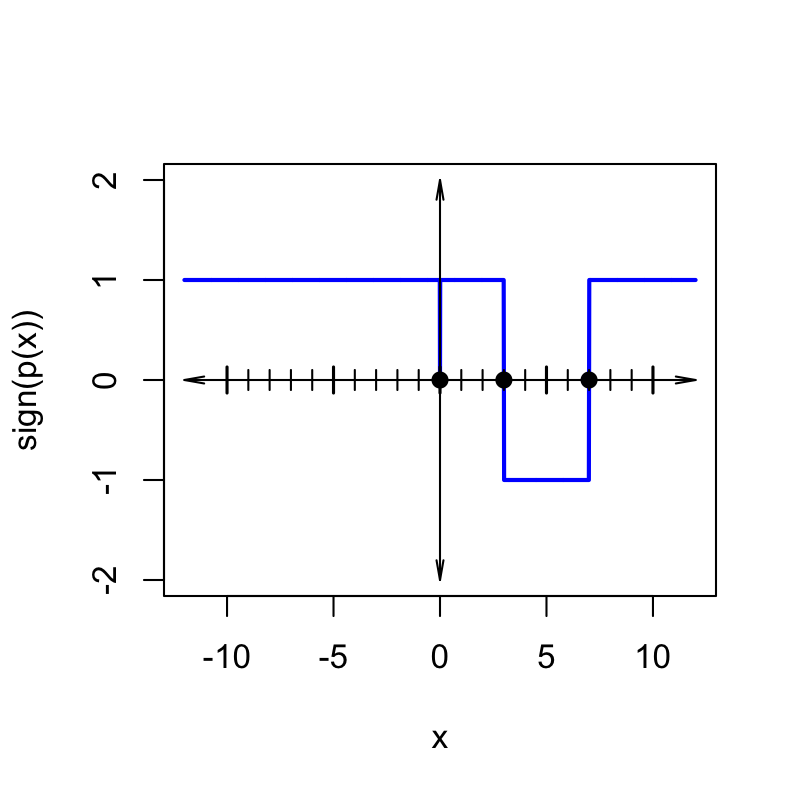

And only one option matches.

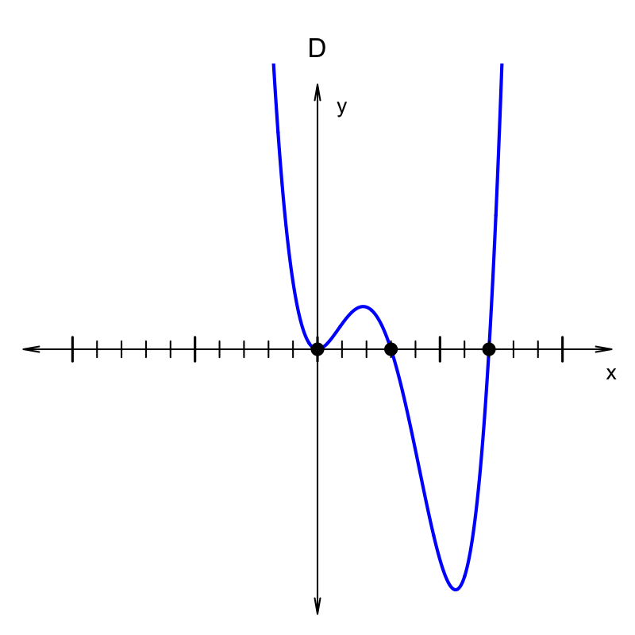

A polynomial, $p(x)$, is given in factored form.
$$p(x)~=~(x+5)\cdot
(x+1)^{2}\cdot (x-6)$$

Which of the following graphs matches $y=p(x)$?

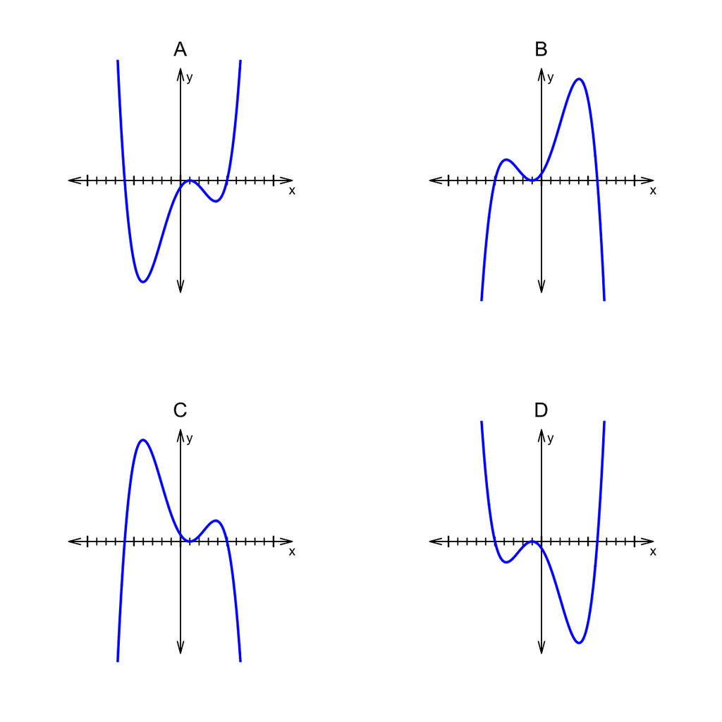

ABCD

First, consider the end behavior. If you expanded the polynomial into standard form, the highest-degree term would be $x^{4}$.

$$p(x)~=~x^{4}+\ldots$$

The highest degree term has a positive coefficient and an even degree, so the end behavior is **"up,up"**. Or, more formally, $\lim\limits_{x\to-\infty} p(x) ~=~ \infty$ and $\lim\limits_{x\to\infty} p(x) ~=~ \infty$.

Next, we consider the roots. From the factored form, $p(x)~=~(x+5)\cdot (x+1)^{2}\cdot (x-6)$, it is easy to see (see [zero-product property](https://en.wikipedia.org/wiki/Zero-product_property)) that $x=-5$ or $x=-1$ or $x=6$ makes the polynomial output 0.

$$p(-5)~=~(-5+5)\cdot (-5+1)^{2}\cdot
(-5-6)~=~0$$
$$p(-1)~=~(-1+5)\cdot
(-1+1)^{2}\cdot (-1-6)~=~0$$
$$p(6)~=~(6+5)\cdot (6+1)^{2}\cdot
(6-6)~=~0$$

We predict that at $x=-1$ there is a double root (multiplicity of 2) because the corresponding factor is squared. Graphically, we expect the curve to "bounce" off the $x$ axis at $x=-1$. At the other roots, we expect the curve to cut through the $x$ axis.

Anyway, based on this analysis, we can produce a [sign](https://en.wikipedia.org/wiki/Sign_function) graph of the polynomial.

| $x$ interval or value | sign analysis of $p(x)~=~(x+5)\cdot (x+1)^{2}\cdot (x-6)$ | sign |
| --- | --- | --- |
| $(-\infty,-5)$ | $(\mathrm{neg})\cdot (\mathrm{neg})^{2}\cdot (\mathrm{neg})$ | $1$ |
| $-5$ | $(\mathrm{zero})\cdot (\mathrm{neg})^{2}\cdot (\mathrm{neg})$ | $0$ |
| $(-5,-1)$ | $(\mathrm{pos})\cdot (\mathrm{neg})^{2}\cdot (\mathrm{neg})$ | $-1$ |
| $-1$ | $(\mathrm{pos})\cdot (\mathrm{zero})^{2}\cdot (\mathrm{neg})$ | $0$ |
| $(-1,6)$ | $(\mathrm{pos})\cdot (\mathrm{pos})^{2}\cdot (\mathrm{neg})$ | $-1$ |
| $6$ | $(\mathrm{pos})\cdot (\mathrm{pos})^{2}\cdot (\mathrm{zero})$ | $0$ |
| $(6,\infty)$ | $(\mathrm{pos})\cdot (\mathrm{pos})^{2}\cdot (\mathrm{pos})$ | $1$ |

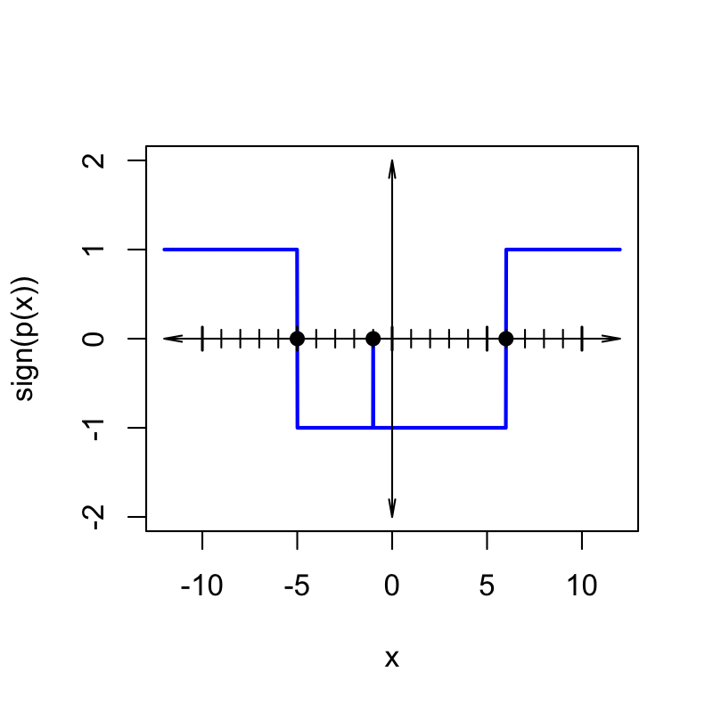

And only one option matches.

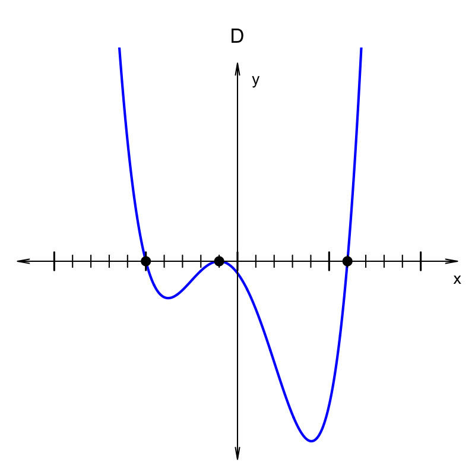

A polynomial, $p(x)$, is given in factored form.
$$p(x)~=~(x+9)^{2}\cdot
(x+1)\cdot (x-3)$$

Which of the following graphs matches $y=p(x)$?

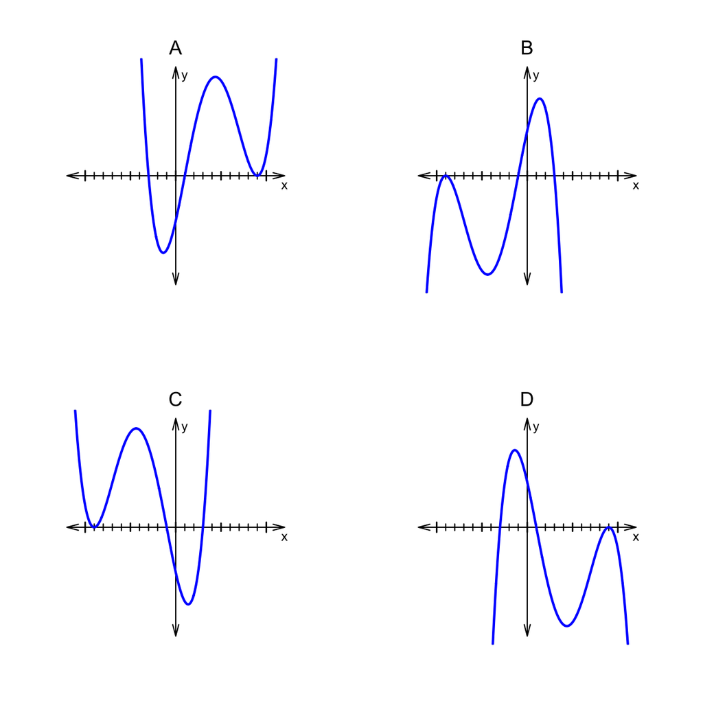

ABCD

First, consider the end behavior. If you expanded the polynomial into standard form, the highest-degree term would be $x^{4}$.

$$p(x)~=~x^{4}+\ldots$$

The highest degree term has a positive coefficient and an even degree, so the end behavior is **"up,up"**. Or, more formally, $\lim\limits_{x\to-\infty} p(x) ~=~ \infty$ and $\lim\limits_{x\to\infty} p(x) ~=~ \infty$.

Next, we consider the roots. From the factored form, $p(x)~=~(x+9)^{2}\cdot (x+1)\cdot (x-3)$, it is easy to see (see [zero-product property](https://en.wikipedia.org/wiki/Zero-product_property)) that $x=-9$ or $x=-1$ or $x=3$ makes the polynomial output 0.

$$p(-9)~=~(-9+9)^{2}\cdot (-9+1)\cdot
(-9-3)~=~0$$
$$p(-1)~=~(-1+9)^{2}\cdot
(-1+1)\cdot (-1-3)~=~0$$
$$p(3)~=~(3+9)^{2}\cdot (3+1)\cdot
(3-3)~=~0$$

We predict that at $x=-9$ there is a double root (multiplicity of 2) because the corresponding factor is squared. Graphically, we expect the curve to "bounce" off the $x$ axis at $x=-9$. At the other roots, we expect the curve to cut through the $x$ axis.

Anyway, based on this analysis, we can produce a [sign](https://en.wikipedia.org/wiki/Sign_function) graph of the polynomial.

| $x$ interval or value | sign analysis of $p(x)~=~(x+9)^{2}\cdot (x+1)\cdot (x-3)$ | sign |
| --- | --- | --- |
| $(-\infty,-9)$ | $(\mathrm{neg})^{2}\cdot (\mathrm{neg})\cdot (\mathrm{neg})$ | $1$ |
| $-9$ | $(\mathrm{zero})^{2}\cdot (\mathrm{neg})\cdot (\mathrm{neg})$ | $0$ |
| $(-9,-1)$ | $(\mathrm{pos})^{2}\cdot (\mathrm{neg})\cdot (\mathrm{neg})$ | $1$ |
| $-1$ | $(\mathrm{pos})^{2}\cdot (\mathrm{zero})\cdot (\mathrm{neg})$ | $0$ |
| $(-1,3)$ | $(\mathrm{pos})^{2}\cdot (\mathrm{pos})\cdot (\mathrm{neg})$ | $-1$ |
| $3$ | $(\mathrm{pos})^{2}\cdot (\mathrm{pos})\cdot (\mathrm{zero})$ | $0$ |
| $(3,\infty)$ | $(\mathrm{pos})^{2}\cdot (\mathrm{pos})\cdot (\mathrm{pos})$ | $1$ |

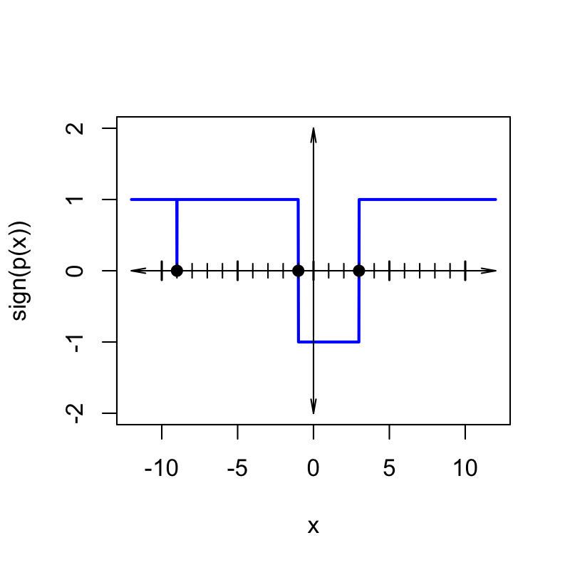

And only one option matches.

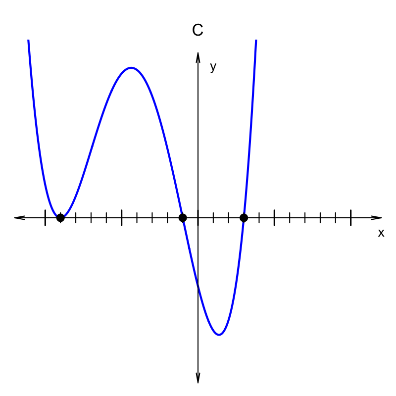

A polynomial, $p(x)$, is given in factored form.
$$p(x)~=~-(x+5)^{2}\cdot
(x-8)$$

Which of the following graphs matches $y=p(x)$?

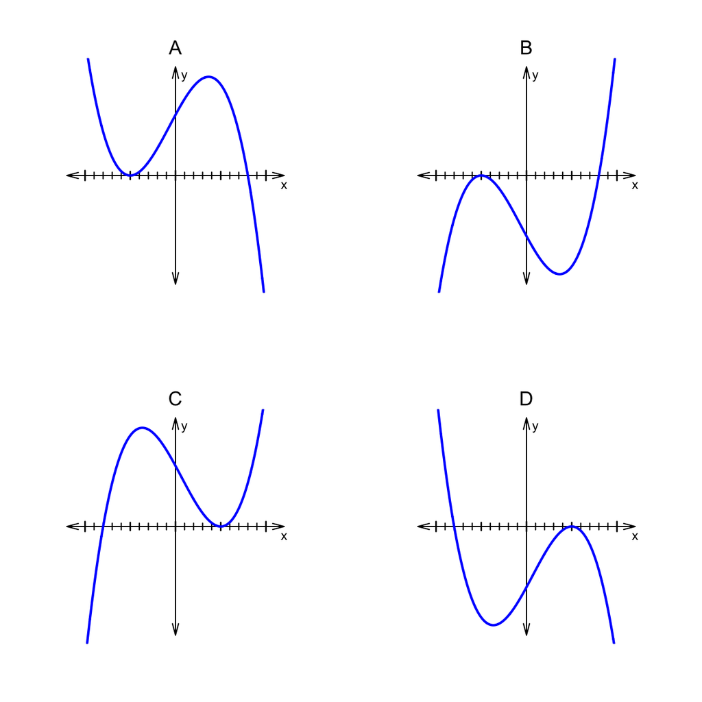

ABCD

First, consider the end behavior. If you expanded the polynomial into standard form, the highest-degree term would be $-x^{3}$.

$$p(x)~=~-x^{3}+\ldots$$

The highest degree term has a negative coefficient and an odd degree, so the end behavior is **"up,down"**. Or, more formally, $\lim\limits_{x\to-\infty} p(x) ~=~ \infty$ and $\lim\limits_{x\to\infty} p(x) ~=~ -\infty$.

Next, we consider the roots. From the factored form, $p(x)~=~-(x+5)^{2}\cdot (x-8)$, it is easy to see (see [zero-product property](https://en.wikipedia.org/wiki/Zero-product_property)) that $x=-5$ or $x=8$ makes the polynomial output 0.

$$p(-5)~=~-(-5+5)^{2}\cdot
(-5-8)~=~0$$
$$p(8)~=~-(8+5)^{2}\cdot
(8-8)~=~0$$

We predict that at $x=-5$ there is a double root (multiplicity of 2) because the corresponding factor is squared. Graphically, we expect the curve to "bounce" off the $x$ axis at $x=-5$. At the other root, we expect the curve to cut through the $x$ axis.

Anyway, based on this analysis, we can produce a [sign](https://en.wikipedia.org/wiki/Sign_function) graph of the polynomial.

| $x$ interval or value | sign analysis of $p(x)~=~-(x+5)^{2}\cdot (x-8)$ | sign |
| --- | --- | --- |
| $(-\infty,-5)$ | $-(\mathrm{neg})^{2}\cdot (\mathrm{neg})$ | $1$ |
| $-5$ | $-(\mathrm{zero})^{2}\cdot (\mathrm{neg})$ | $0$ |
| $(-5,8)$ | $-(\mathrm{pos})^{2}\cdot (\mathrm{neg})$ | $1$ |
| $8$ | $-(\mathrm{pos})^{2}\cdot (\mathrm{zero})$ | $0$ |
| $(8,\infty)$ | $-(\mathrm{pos})^{2}\cdot (\mathrm{pos})$ | $-1$ |

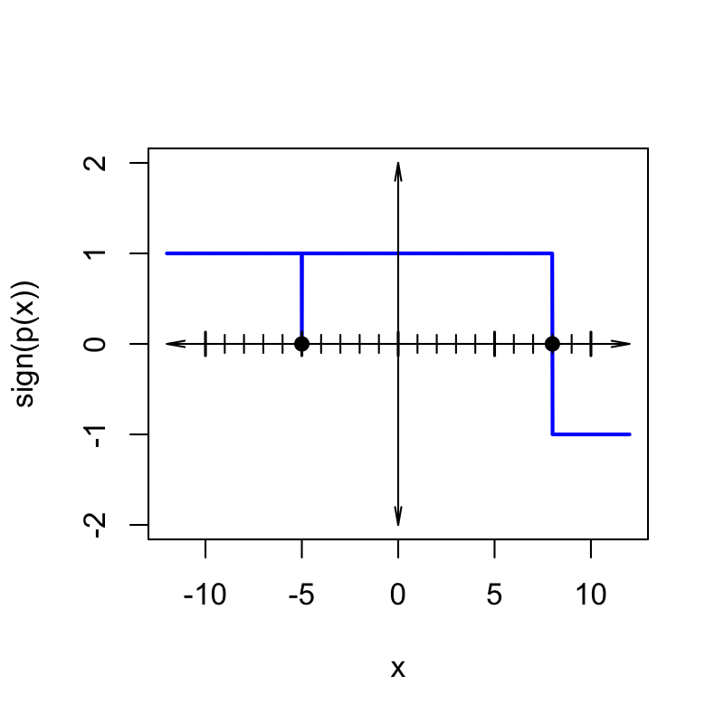

And only one option matches.

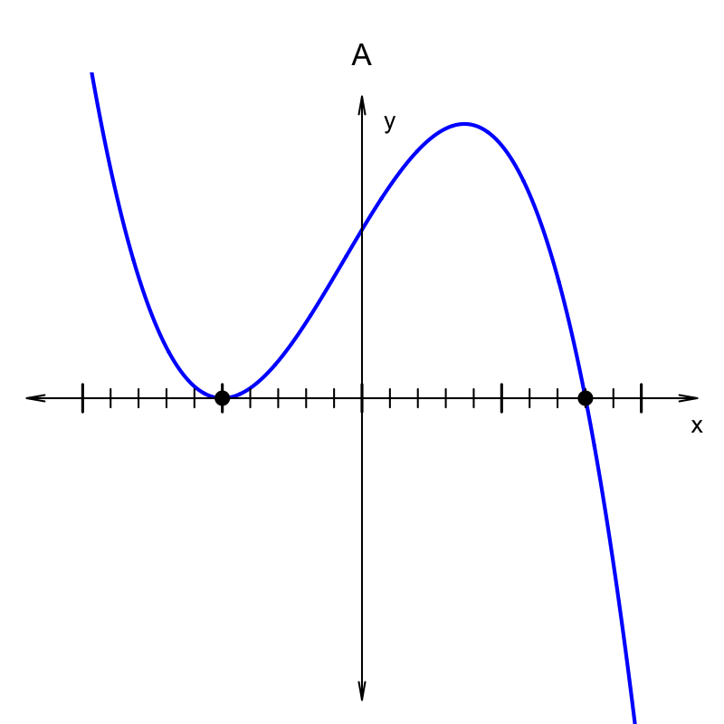

A polynomial, $p(x)$, is given in factored form.
$$p(x)~=~-(x+1)\cdot
(x-7)^{2}$$

Which of the following graphs matches $y=p(x)$?

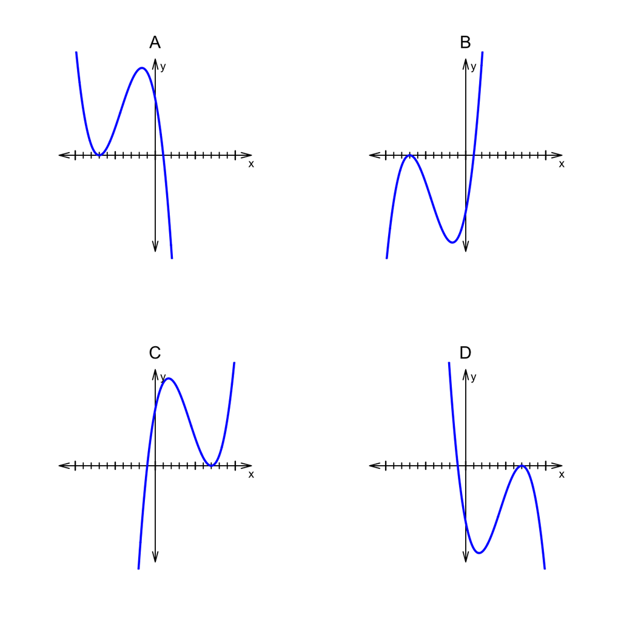

ABCD

First, consider the end behavior. If you expanded the polynomial into standard form, the highest-degree term would be $-x^{3}$.

$$p(x)~=~-x^{3}+\ldots$$

The highest degree term has a negative coefficient and an odd degree, so the end behavior is **"up,down"**. Or, more formally, $\lim\limits_{x\to-\infty} p(x) ~=~ \infty$ and $\lim\limits_{x\to\infty} p(x) ~=~ -\infty$.

Next, we consider the roots. From the factored form, $p(x)~=~-(x+1)\cdot (x-7)^{2}$, it is easy to see (see [zero-product property](https://en.wikipedia.org/wiki/Zero-product_property)) that $x=-1$ or $x=7$ makes the polynomial output 0.

$$p(-1)~=~-(-1+1)\cdot
(-1-7)^{2}~=~0$$
$$p(7)~=~-(7+1)\cdot
(7-7)^{2}~=~0$$

We predict that at $x=7$ there is a double root (multiplicity of 2) because the corresponding factor is squared. Graphically, we expect the curve to "bounce" off the $x$ axis at $x=7$. At the other root, we expect the curve to cut through the $x$ axis.

Anyway, based on this analysis, we can produce a [sign](https://en.wikipedia.org/wiki/Sign_function) graph of the polynomial.

| $x$ interval or value | sign analysis of $p(x)~=~-(x+1)\cdot (x-7)^{2}$ | sign |
| --- | --- | --- |
| $(-\infty,-1)$ | $-(\mathrm{neg})\cdot (\mathrm{neg})^{2}$ | $1$ |
| $-1$ | $-(\mathrm{zero})\cdot (\mathrm{neg})^{2}$ | $0$ |
| $(-1,7)$ | $-(\mathrm{pos})\cdot (\mathrm{neg})^{2}$ | $-1$ |
| $7$ | $-(\mathrm{pos})\cdot (\mathrm{zero})^{2}$ | $0$ |
| $(7,\infty)$ | $-(\mathrm{pos})\cdot (\mathrm{pos})^{2}$ | $-1$ |

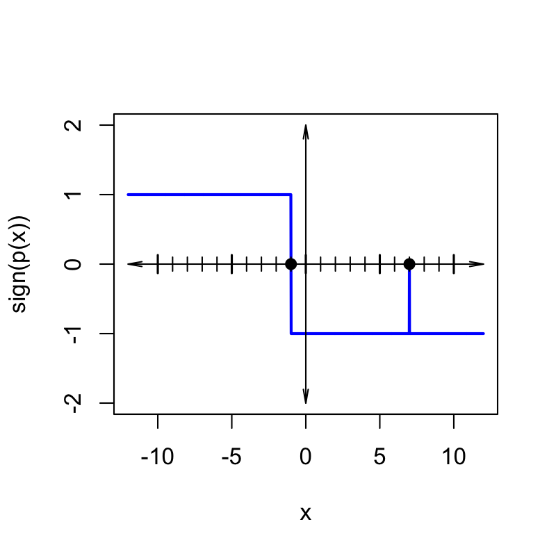

And only one option matches.

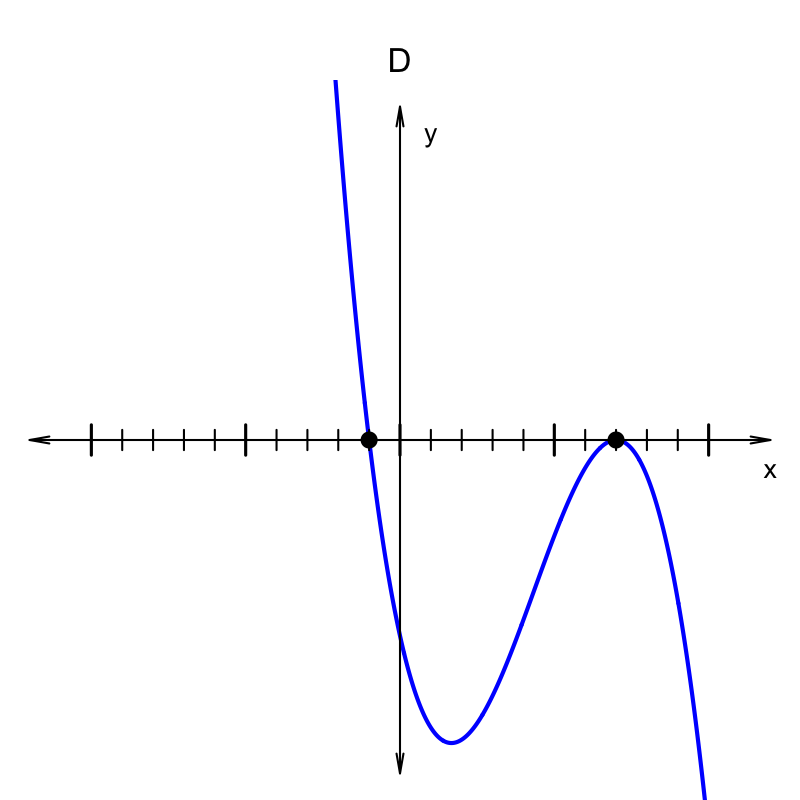

A polynomial, $p(x)$, is given in factored form.
$$p(x)~=~-(x+4)\cdot
(x-2)^{2}$$

Which of the following graphs matches $y=p(x)$?

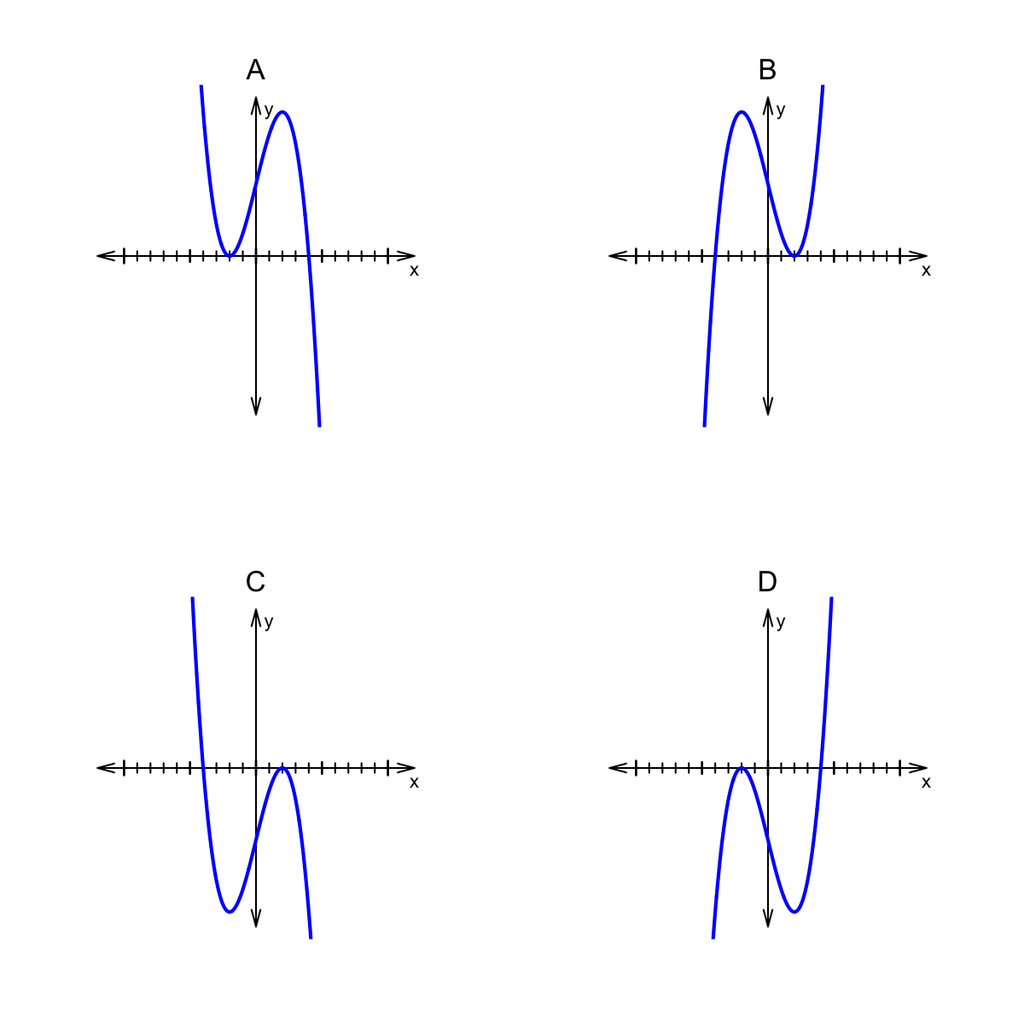

ABCD

First, consider the end behavior. If you expanded the polynomial into standard form, the highest-degree term would be $-x^{3}$.

$$p(x)~=~-x^{3}+\ldots$$

The highest degree term has a negative coefficient and an odd degree, so the end behavior is **"up,down"**. Or, more formally, $\lim\limits_{x\to-\infty} p(x) ~=~ \infty$ and $\lim\limits_{x\to\infty} p(x) ~=~ -\infty$.

Next, we consider the roots. From the factored form, $p(x)~=~-(x+4)\cdot (x-2)^{2}$, it is easy to see (see [zero-product property](https://en.wikipedia.org/wiki/Zero-product_property)) that $x=-4$ or $x=2$ makes the polynomial output 0.

$$p(-4)~=~-(-4+4)\cdot
(-4-2)^{2}~=~0$$
$$p(2)~=~-(2+4)\cdot
(2-2)^{2}~=~0$$

We predict that at $x=2$ there is a double root (multiplicity of 2) because the corresponding factor is squared. Graphically, we expect the curve to "bounce" off the $x$ axis at $x=2$. At the other root, we expect the curve to cut through the $x$ axis.

Anyway, based on this analysis, we can produce a [sign](https://en.wikipedia.org/wiki/Sign_function) graph of the polynomial.

| $x$ interval or value | sign analysis of $p(x)~=~-(x+4)\cdot (x-2)^{2}$ | sign |
| --- | --- | --- |
| $(-\infty,-4)$ | $-(\mathrm{neg})\cdot (\mathrm{neg})^{2}$ | $1$ |
| $-4$ | $-(\mathrm{zero})\cdot (\mathrm{neg})^{2}$ | $0$ |
| $(-4,2)$ | $-(\mathrm{pos})\cdot (\mathrm{neg})^{2}$ | $-1$ |
| $2$ | $-(\mathrm{pos})\cdot (\mathrm{zero})^{2}$ | $0$ |
| $(2,\infty)$ | $-(\mathrm{pos})\cdot (\mathrm{pos})^{2}$ | $-1$ |

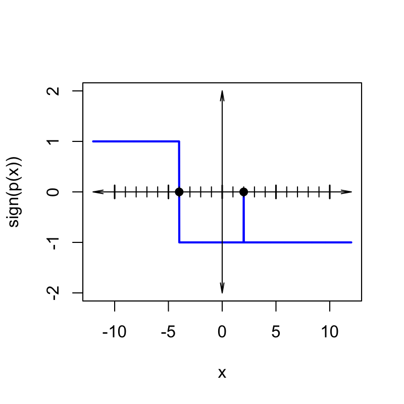

And only one option matches.

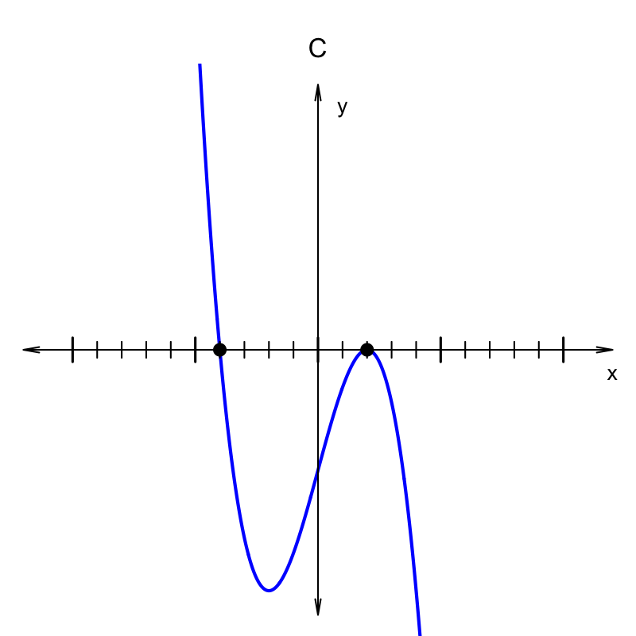

A polynomial, $p(x)$, is given in factored form.
$$p(x)~=~(x+8)^{2}\cdot
(x+5)\cdot (x+2)$$

Which of the following graphs matches $y=p(x)$?

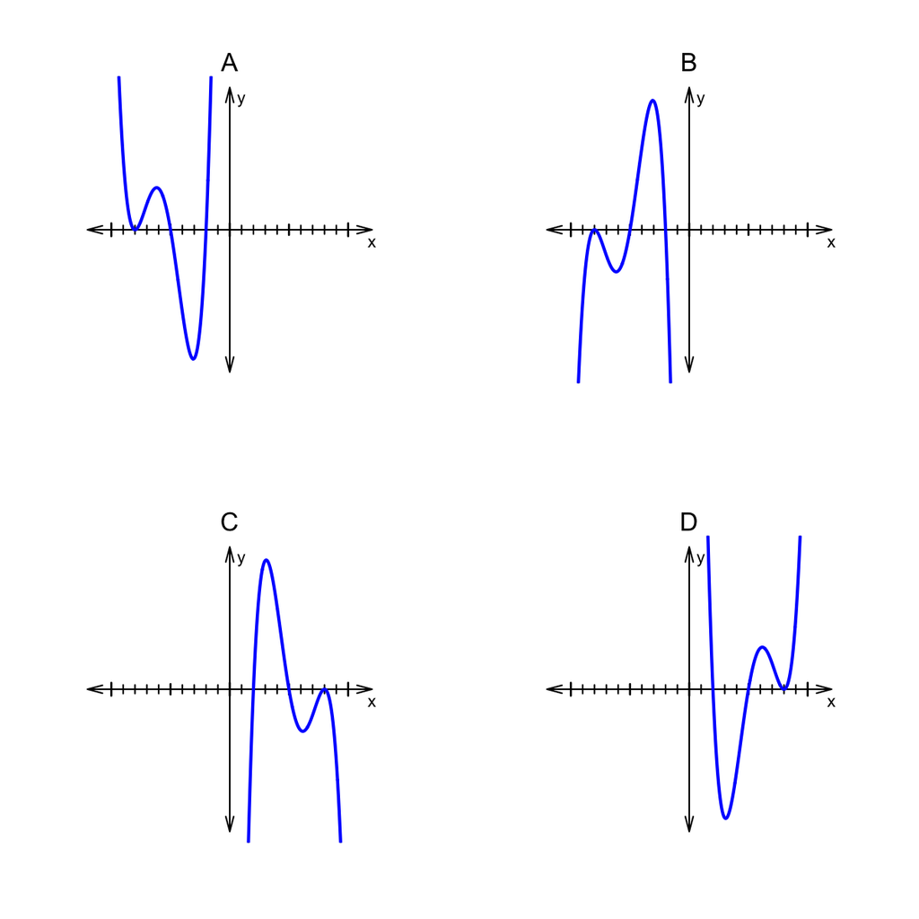

ABCD

First, consider the end behavior. If you expanded the polynomial into standard form, the highest-degree term would be $x^{4}$.

$$p(x)~=~x^{4}+\ldots$$

The highest degree term has a positive coefficient and an even degree, so the end behavior is **"up,up"**. Or, more formally, $\lim\limits_{x\to-\infty} p(x) ~=~ \infty$ and $\lim\limits_{x\to\infty} p(x) ~=~ \infty$.

Next, we consider the roots. From the factored form, $p(x)~=~(x+8)^{2}\cdot (x+5)\cdot (x+2)$, it is easy to see (see [zero-product property](https://en.wikipedia.org/wiki/Zero-product_property)) that $x=-8$ or $x=-5$ or $x=-2$ makes the polynomial output 0.

$$p(-8)~=~(-8+8)^{2}\cdot (-8+5)\cdot
(-8+2)~=~0$$
$$p(-5)~=~(-5+8)^{2}\cdot
(-5+5)\cdot (-5+2)~=~0$$
$$p(-2)~=~(-2+8)^{2}\cdot (-2+5)\cdot
(-2+2)~=~0$$

We predict that at $x=-8$ there is a double root (multiplicity of 2) because the corresponding factor is squared. Graphically, we expect the curve to "bounce" off the $x$ axis at $x=-8$. At the other roots, we expect the curve to cut through the $x$ axis.

Anyway, based on this analysis, we can produce a [sign](https://en.wikipedia.org/wiki/Sign_function) graph of the polynomial.

| $x$ interval or value | sign analysis of $p(x)~=~(x+8)^{2}\cdot (x+5)\cdot (x+2)$ | sign |
| --- | --- | --- |
| $(-\infty,-8)$ | $(\mathrm{neg})^{2}\cdot (\mathrm{neg})\cdot (\mathrm{neg})$ | $1$ |
| $-8$ | $(\mathrm{zero})^{2}\cdot (\mathrm{neg})\cdot (\mathrm{neg})$ | $0$ |
| $(-8,-5)$ | $(\mathrm{pos})^{2}\cdot (\mathrm{neg})\cdot (\mathrm{neg})$ | $1$ |
| $-5$ | $(\mathrm{pos})^{2}\cdot (\mathrm{zero})\cdot (\mathrm{neg})$ | $0$ |
| $(-5,-2)$ | $(\mathrm{pos})^{2}\cdot (\mathrm{pos})\cdot (\mathrm{neg})$ | $-1$ |
| $-2$ | $(\mathrm{pos})^{2}\cdot (\mathrm{pos})\cdot (\mathrm{zero})$ | $0$ |
| $(-2,\infty)$ | $(\mathrm{pos})^{2}\cdot (\mathrm{pos})\cdot (\mathrm{pos})$ | $1$ |

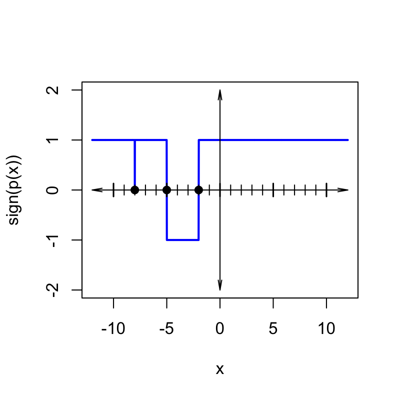

And only one option matches.

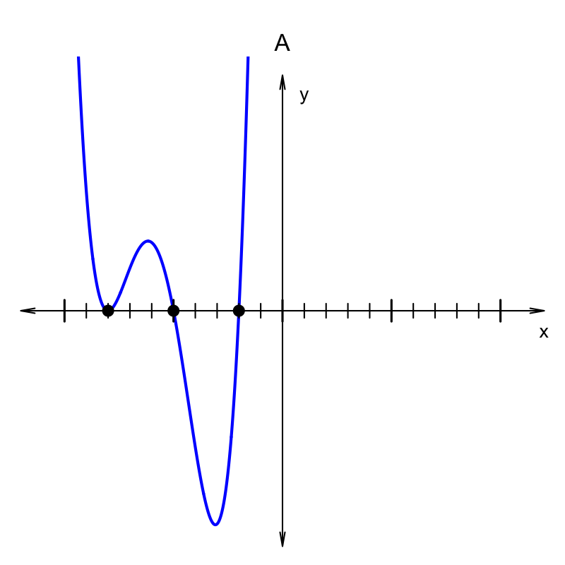

A polynomial, $p(x)$, is given in factored form.
$$p(x)~=~(x-4)\cdot
(x-9)^{2}$$

Which of the following graphs matches $y=p(x)$?

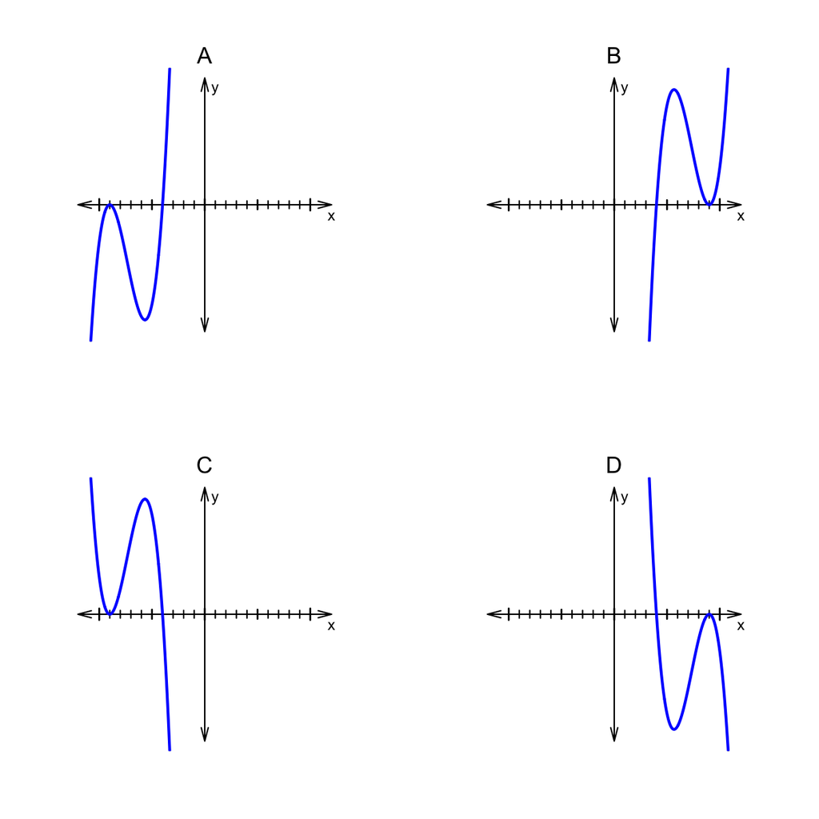

ABCD

First, consider the end behavior. If you expanded the polynomial into standard form, the highest-degree term would be $x^{3}$.

$$p(x)~=~x^{3}+\ldots$$

The highest degree term has a positive coefficient and an odd degree, so the end behavior is **"down,up"**. Or, more formally, $\lim\limits_{x\to-\infty} p(x) ~=~ -\infty$ and $\lim\limits_{x\to\infty} p(x) ~=~ \infty$.

Next, we consider the roots. From the factored form, $p(x)~=~(x-4)\cdot (x-9)^{2}$, it is easy to see (see [zero-product property](https://en.wikipedia.org/wiki/Zero-product_property)) that $x=4$ or $x=9$ makes the polynomial output 0.

$$p(4)~=~(4-4)\cdot (4-9)^{2}~=~0$$
$$p(9)~=~(9-4)\cdot
(9-9)^{2}~=~0$$

We predict that at $x=9$ there is a double root (multiplicity of 2) because the corresponding factor is squared. Graphically, we expect the curve to "bounce" off the $x$ axis at $x=9$. At the other root, we expect the curve to cut through the $x$ axis.

Anyway, based on this analysis, we can produce a [sign](https://en.wikipedia.org/wiki/Sign_function) graph of the polynomial.

| $x$ interval or value | sign analysis of $p(x)~=~(x-4)\cdot (x-9)^{2}$ | sign |
| --- | --- | --- |
| $(-\infty,4)$ | $(\mathrm{neg})\cdot (\mathrm{neg})^{2}$ | $-1$ |
| $4$ | $(\mathrm{zero})\cdot (\mathrm{neg})^{2}$ | $0$ |
| $(4,9)$ | $(\mathrm{pos})\cdot (\mathrm{neg})^{2}$ | $1$ |
| $9$ | $(\mathrm{pos})\cdot (\mathrm{zero})^{2}$ | $0$ |
| $(9,\infty)$ | $(\mathrm{pos})\cdot (\mathrm{pos})^{2}$ | $1$ |

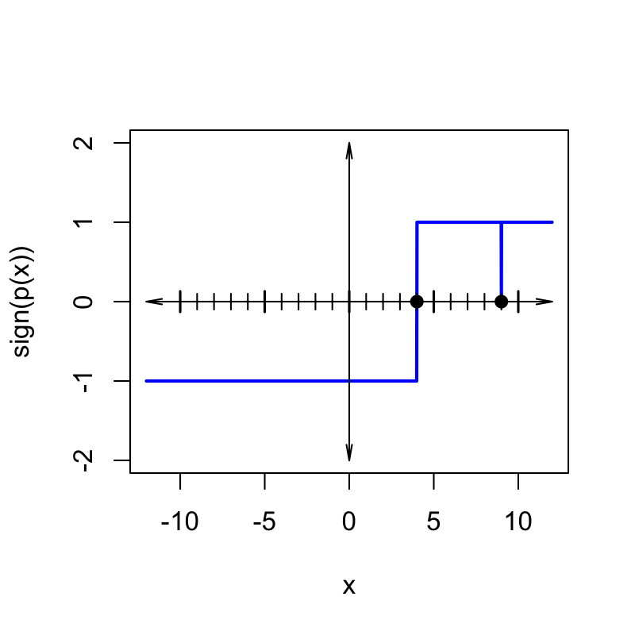

And only one option matches.

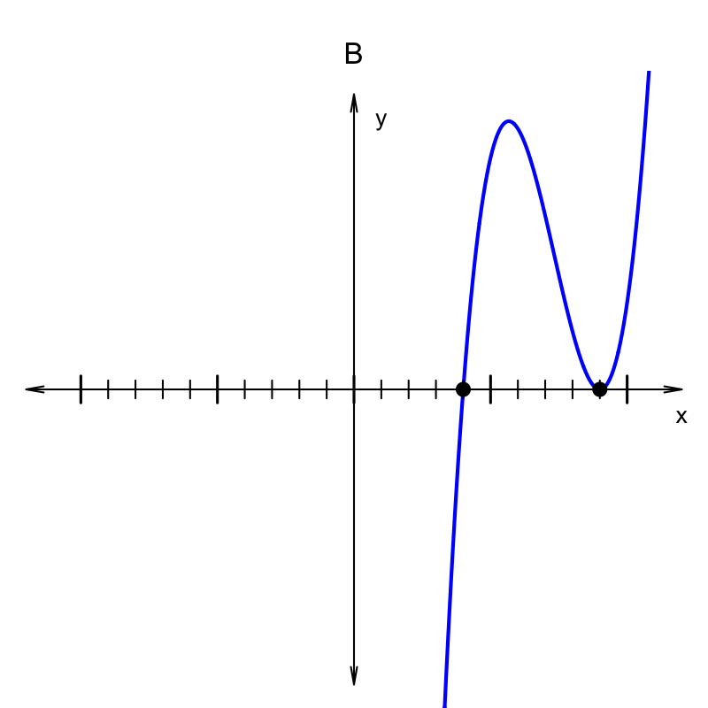

A polynomial, $p(x)$, is given in factored form.
$$p(x)~=~(x-3)^{2}\cdot
(x-7)$$

Which of the following graphs matches $y=p(x)$?

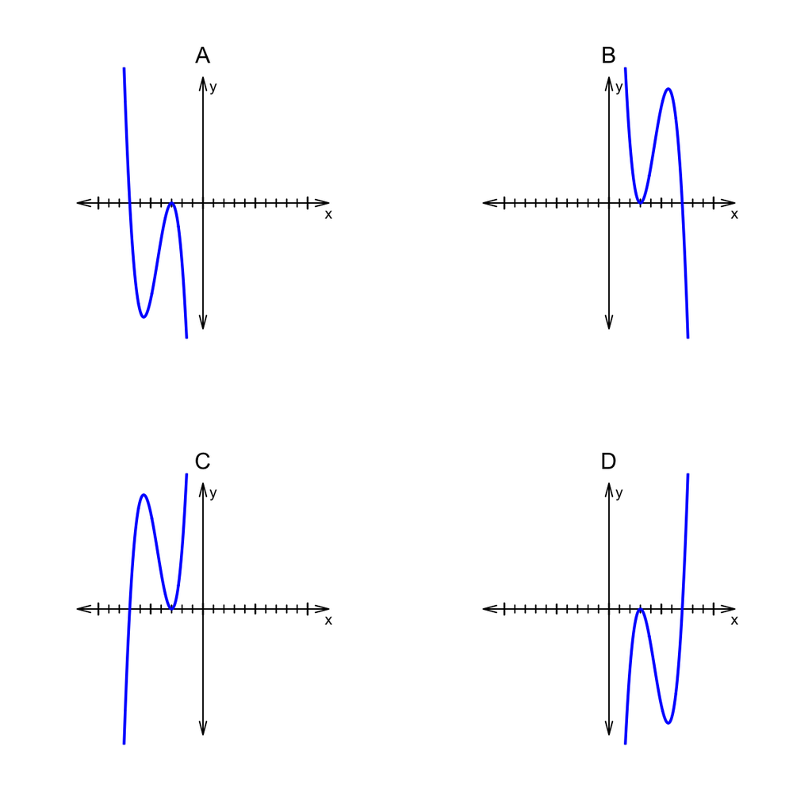

ABCD

First, consider the end behavior. If you expanded the polynomial into standard form, the highest-degree term would be $x^{3}$.

$$p(x)~=~x^{3}+\ldots$$

The highest degree term has a positive coefficient and an odd degree, so the end behavior is **"down,up"**. Or, more formally, $\lim\limits_{x\to-\infty} p(x) ~=~ -\infty$ and $\lim\limits_{x\to\infty} p(x) ~=~ \infty$.

Next, we consider the roots. From the factored form, $p(x)~=~(x-3)^{2}\cdot (x-7)$, it is easy to see (see [zero-product property](https://en.wikipedia.org/wiki/Zero-product_property)) that $x=3$ or $x=7$ makes the polynomial output 0.

$$p(3)~=~(3-3)^{2}\cdot (3-7)~=~0$$
$$p(7)~=~(7-3)^{2}\cdot
(7-7)~=~0$$

We predict that at $x=3$ there is a double root (multiplicity of 2) because the corresponding factor is squared. Graphically, we expect the curve to "bounce" off the $x$ axis at $x=3$. At the other root, we expect the curve to cut through the $x$ axis.

Anyway, based on this analysis, we can produce a [sign](https://en.wikipedia.org/wiki/Sign_function) graph of the polynomial.

| $x$ interval or value | sign analysis of $p(x)~=~(x-3)^{2}\cdot (x-7)$ | sign |
| --- | --- | --- |
| $(-\infty,3)$ | $(\mathrm{neg})^{2}\cdot (\mathrm{neg})$ | $-1$ |
| $3$ | $(\mathrm{zero})^{2}\cdot (\mathrm{neg})$ | $0$ |
| $(3,7)$ | $(\mathrm{pos})^{2}\cdot (\mathrm{neg})$ | $-1$ |
| $7$ | $(\mathrm{pos})^{2}\cdot (\mathrm{zero})$ | $0$ |
| $(7,\infty)$ | $(\mathrm{pos})^{2}\cdot (\mathrm{pos})$ | $1$ |

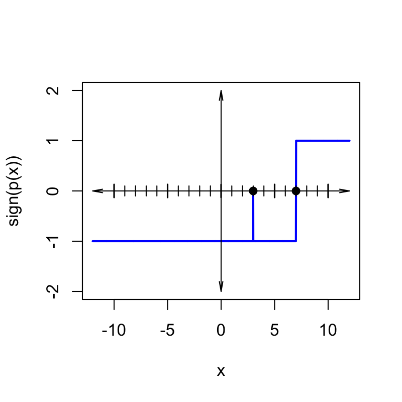

And only one option matches.

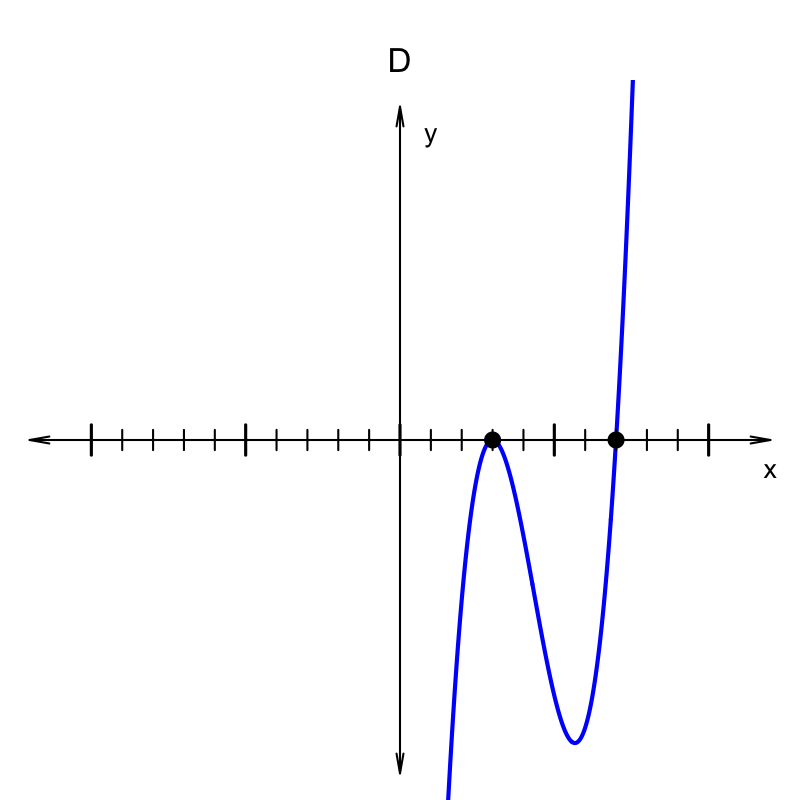

A polynomial, $p(x)$, is given in factored form.
$$p(x)~=~-(x+2)\cdot
(x-7)^{2}$$